# Arbuscular mycorrhizal fungi colonization package

Marco Chiapello

5 December 2017

# Contents

### 0.0.1 Introduction

The package is meant to help scientists to compute the degree of arbuscular mycorrhizal colonization, producing tables, robust statistics and different kind of plots.

All the functions of the package work independently of the colonization scoring system.

#### 0.0.1.1 Grid scoring system

The data should be provided in a **csv table** like the follow one:

| samples | replicates | Total | Hyphopodia | IntrHyphae | Arbuscule | Vesicle |
| --- | --- | --- | --- | --- | --- | --- |
| WT | A | 30 | 3 | 30 | 30 | 10 |
| WT | A | 24 | 5 | 24 | 24 | 7 |
| WT | B | 20 | 2 | 20 | 20 | 5 |
| WT | B | 15 | 2 | 15 | 15 | 3 |
| cyclops-3 | A | 18 | 6 | 18 | 9 | 0 |
| cyclops-3 | A | 16 | 10 | 10 | 0 | 0 |
| cyclops-3 | B | 20 | 12 | 20 | 0 | 0 |
| cyclops-3 | B | 14 | 4 | 14 | 0 | 0 |
| … | … | … | … | … | … | … |

The table contains:

- 7 columns with **specific headers**
- The first 2 columns (samples and replicates) must be present
- The last 5 columns (Total, Hyphopodia, IntHyphae, Arbuscule and Vesicle) could not be all present
- If the headers are not the same of the ones in the example table the software will not be able to read the table
- As many row as you need
- The **first element of column “samples” will be used as control** for the statistical analysis (in this example “WT” will be used as control)

#### 0.0.1.2 Trouvelot scoring system

| samples | replicates | scoring |
| --- | --- | --- |
| Lys11 | A | 1A3 |
| Lys11 | A | 5A3 |
| Lys11 | A | 0A0 |
| Lys11 | B | 3A2 |
| Lys11 | B | 3A3 |
| Lys11 | B | 4A3 |
| GiFu | A | 0A0 |
| GiFu | A | 0A0 |
| GiFu | A | 1A3 |
| GiFu | B | 3A3 |
| GiFu | B | 0A0 |
| GiFu | B | 0A0 |
| … | … | … |

### 0.0.2 Loading the data

To load data in, use the follow command:

> readData(file.csv, type = c(“grid”, “trouvelot”))

#### 0.0.2.1 Example

```r
# Grid
f <- dir(system.file("extdata", package = "Ramf"), full.names = TRUE, pattern = "grid.csv")
gr <- readData(f, type = "grid")
# Grid incomplete
f <- dir(system.file("extdata", package = "Ramf"), full.names = TRUE, pattern = "grid_incomplete.csv")
gri <- readData(f, type = "grid")
# Trouvelot
f <- dir(system.file("extdata", package = "Ramf"), full.names = TRUE, pattern = "trouvelot.csv")
tr <- readData(f, type = "trouvelot")
```

It is very important the order of the samples in the csv file. The first sample will be considered the control.

### 0.0.3 Summarize data

To summarise the data and export the scoring results in a tabular format use the follow command:

> am_summary

#### 0.0.3.1 Example

```r
grs <- am_summary(gr)
gris <- am_summary(gri)
trs <- am_summary(tr)
grs
```

```
## $`Summary per Replicate`
## # A tibble: 12 x 7
##      samples replicates     Total Hyphopodia IntrHyphae Arbuscule   Vesicle
##        <chr>      <chr>     <dbl>      <dbl>      <dbl>     <dbl>     <dbl>
##  1        WT          A 23.000000   3.333333   23.00000  23.00000  6.666667
##  2        WT          B 39.666667   3.333333   39.66667  38.66667 10.333333
##  3        WT          C 27.333333   3.666667   27.33333  27.33333  6.000000
##  4 cyclops-3          A 21.333333  12.000000   19.33333   0.00000  0.000000
##  5 cyclops-3          B 24.666667  13.000000   24.66667   0.00000  0.000000
##  6 cyclops-3          C 10.000000   5.000000   10.00000   0.00000  0.000000
##  7 cyclops-4          A 14.000000   3.333333   14.00000   0.00000  0.000000
##  8 cyclops-4          B 20.333333  10.666667   17.33333   0.00000  0.000000
##  9 cyclops-4          C 13.666667   4.333333   13.66667   0.00000  0.000000
## 10  ccamk-13          A  9.333333   9.333333    0.00000   0.00000  0.000000
## 11  ccamk-13          B 10.333333  10.333333    0.00000   0.00000  0.000000
## 12  ccamk-13          C 15.000000  15.000000    0.00000   0.00000  0.000000
##
## $`Summary per Sample`
## # A tibble: 4 x 11
##     samples Total_mean Hyphopodia_mean IntrHyphae_mean Arbuscule_mean
##       <chr>      <dbl>           <dbl>           <dbl>          <dbl>
## 1        WT   30.00000        3.444444              30       29.66667
## 2 cyclops-3   18.66667       10.000000              18        0.00000
## 3 cyclops-4   16.00000        6.111111              15        0.00000
## 4  ccamk-13   11.55556       11.555556               0        0.00000
## # ... with 6 more variables: Vesicle_mean <dbl>, Total_se <dbl>,
## #   Hyphopodia_se <dbl>, IntrHyphae_se <dbl>, Arbuscule_se <dbl>,
## #   Vesicle_se <dbl>
##
## attr(,"class")
## [1] "am_summary" "list"
```

```r
gris
```

```
## $`Summary per Replicate`
## # A tibble: 12 x 6
##      samples replicates     Total IntrHyphae Arbuscule   Vesicle
##        <chr>      <chr>     <dbl>      <dbl>     <dbl>     <dbl>
##  1        WT          A 23.000000   23.00000  23.00000  6.666667
##  2        WT          B 39.666667   39.66667  38.66667 10.333333
##  3        WT          C 27.333333   27.33333  27.33333  6.000000
##  4 cyclops-3          A 21.333333   19.33333   0.00000  0.000000
##  5 cyclops-3          B 24.666667   24.66667   0.00000  0.000000
##  6 cyclops-3          C 10.000000   10.00000   0.00000  0.000000
##  7 cyclops-4          A 14.000000   14.00000   0.00000  0.000000
##  8 cyclops-4          B 20.333333   17.33333   0.00000  0.000000
##  9 cyclops-4          C 13.666667   13.66667   0.00000  0.000000
## 10  ccamk-13          A  9.333333    0.00000   0.00000  0.000000
## 11  ccamk-13          B 10.333333    0.00000   0.00000  0.000000
## 12  ccamk-13          C 15.000000    0.00000   0.00000  0.000000
##
## $`Summary per Sample`
## # A tibble: 4 x 9
##     samples Total_mean IntrHyphae_mean Arbuscule_mean Vesicle_mean Total_se
##       <chr>      <dbl>           <dbl>          <dbl>        <dbl>    <dbl>
## 1        WT   30.00000              30       29.66667     7.666667 4.992587
## 2 cyclops-3   18.66667              18        0.00000     0.000000 4.438885
## 3 cyclops-4   16.00000              15        0.00000     0.000000 2.168802
## 4  ccamk-13   11.55556               0        0.00000     0.000000 1.746248
## # ... with 3 more variables: IntrHyphae_se <dbl>, Arbuscule_se <dbl>,
## #   Vesicle_se <dbl>
##
## attr(,"class")
## [1] "am_summary" "list"
```

```r
trs
```

```
## $`Summary per Replicate`
## # A tibble: 9 x 6
## # Groups:   samples [3]
##   samples replicates     F     M      a     A
##     <chr>      <chr> <dbl> <dbl>  <dbl> <dbl>
## 1  Lys 11          A 59.68 26.65  99.09 26.41
## 2  Lys 11          B 52.56  5.29 100.00  5.29
## 3  Lys 11          C 75.14 31.58 100.00 31.58
## 4      TM          A 61.54 23.54 100.00 23.54
## 5      TM          B 65.82 22.00 100.00 22.00
## 6      TM          C 77.50 27.24 100.00 27.24
## 7    Gifu          A 83.66 32.29  96.80 31.25
## 8    Gifu          B 95.33 52.49 100.00 52.49
## 9    Gifu          C 80.65 41.14 100.00 41.14
##
## $`Summary per Sample`
## # A tibble: 3 x 9
##   samples `Mean F` `Standard error F` `Mean M` `Standard error M` `Mean a`
##     <chr>    <dbl>              <dbl>    <dbl>              <dbl>    <dbl>
## 1  Lys 11    62.46               6.66    21.17               8.07    99.70
## 2      TM    68.29               4.77    24.26               1.55   100.00
## 3    Gifu    86.55               4.48    41.97               5.85    98.93
## # ... with 3 more variables: `Standar error a` <dbl>, `Mean A` <dbl>,
## #   `Standard error A` <dbl>
##
## attr(,"class")
## [1] "am_summary" "list"
```

### 0.0.4 Statistical analysis

The statistical analysis is performed using the `kruskal` function from `agricolae` package. To read more about the statatical framework, refer to this [link](https://en.wikipedia.org/wiki/Kruskal%E2%80%93Wallis_one-way_analysis_of_variance).

> am_stat

#### 0.0.4.1 Example

```r
grst <- am_stat(gr)
grist <- am_stat(gri)
trst <- am_stat(tr)
grst
```

```
##      group1    group2 Total.pval Hyphopodia.pval IntrHyphae.pval
## 1        WT cyclops-3     0.1029          0.0184          0.0509
## 2        WT cyclops-4     0.0397          0.2495          0.0124
## 3        WT  ccamk-13     0.0097          0.0184          0.0003
## 4 cyclops-3 cyclops-4     0.5565          0.1261          0.3856
## 5 cyclops-3  ccamk-13     0.1636          1.0000          0.0063
## 6 cyclops-4  ccamk-13     0.3843          0.1261          0.0249
##   Arbuscule.pval Vesicle.pval
## 1              0            0
## 2              0            0
## 3              0            0
## 4              1            1
## 5              1            1
## 6              1            1
```

```r
grist
```

```
##      group1    group2 Total.pval IntrHyphae.pval Arbuscule.pval Vesicle.pval
## 1        WT cyclops-3     0.1029          0.0509              0            0
## 2        WT cyclops-4     0.0397          0.0124              0            0
## 3        WT  ccamk-13     0.0097          0.0003              0            0
## 4 cyclops-3 cyclops-4     0.5565          0.3856              1            1
## 5 cyclops-3  ccamk-13     0.1636          0.0063              1            1
## 6 cyclops-4  ccamk-13     0.3843          0.0249              1            1
```

```r
trst
```

```
##   group1 group2 F.pval M.pval a.pval A.pval
## 1 Lys 11     TM 0.2488 0.8276 0.4732 0.7152
## 2 Lys 11   Gifu 0.0065 0.0254 0.8546 0.0800
## 3     TM   Gifu 0.0308 0.0190 0.3758 0.0474
```

By default, the correction method is “none”, but it is possible to select between: Bonferroni, Holm, Hochberg, Bonferroni, Benjamini-Hochberg, Benjamini-Yekutieli or fdr adjustment. For more details refer to [agricolae package](https://cran.r-project.org/web/packages/agricolae/index.html).

#### 0.0.4.2 Example

```r
am_stat(gr, method = "BH")
```

```
##      group1    group2 Total.pval Hyphopodia.pval IntrHyphae.pval
## 1        WT cyclops-3     0.2059          0.0553          0.0611
## 2        WT cyclops-4     0.1190          0.2994          0.0248
## 3        WT  ccamk-13     0.0583          0.0553          0.0020
## 4 cyclops-3 cyclops-4     0.5565          0.1892          0.3856
## 5 cyclops-3  ccamk-13     0.2454          1.0000          0.0189
## 6 cyclops-4  ccamk-13     0.4612          0.1892          0.0374
##   Arbuscule.pval Vesicle.pval
## 1              0            0
## 2              0            0
## 3              0            0
## 4              1            1
## 5              1            1
## 6              1            1
```

```r
am_stat(gri, method = "BH")
```

```
##      group1    group2 Total.pval IntrHyphae.pval Arbuscule.pval Vesicle.pval
## 1        WT cyclops-3     0.2059          0.0611              0            0
## 2        WT cyclops-4     0.1190          0.0248              0            0
## 3        WT  ccamk-13     0.0583          0.0020              0            0
## 4 cyclops-3 cyclops-4     0.5565          0.3856              1            1
## 5 cyclops-3  ccamk-13     0.2454          0.0189              1            1
## 6 cyclops-4  ccamk-13     0.4612          0.0374              1            1
```

```r
am_stat(tr, method = "fdr")
```

```
##   group1 group2 F.pval M.pval a.pval A.pval
## 1 Lys 11     TM 0.2488 0.8276 0.7098 0.7152
## 2 Lys 11   Gifu 0.0194 0.0381 0.8546 0.1201
## 3     TM   Gifu 0.0462 0.0381 0.7098 0.1201
```

### 0.0.5 Plot data

To summarise the data in a graphical way the package provide 3 plot types:

- barplot

> am_barplot
- boxplot

> am_boxplot
- dotplot

> am_dotplot

It is possible to plot a simple plot.

#### 0.0.5.1 Example

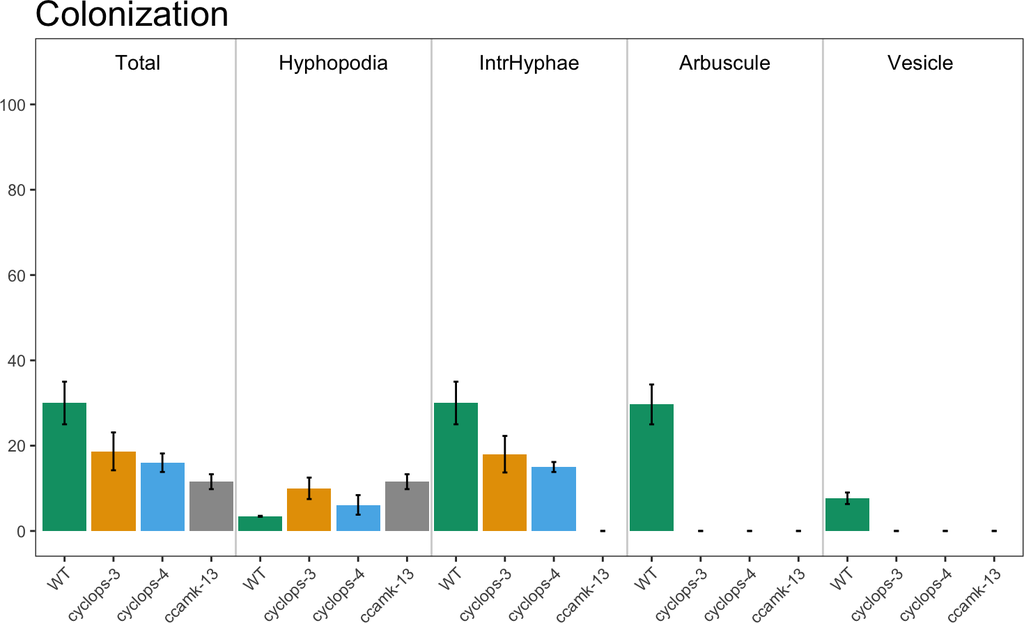

```r
am_barplot(gr)
```

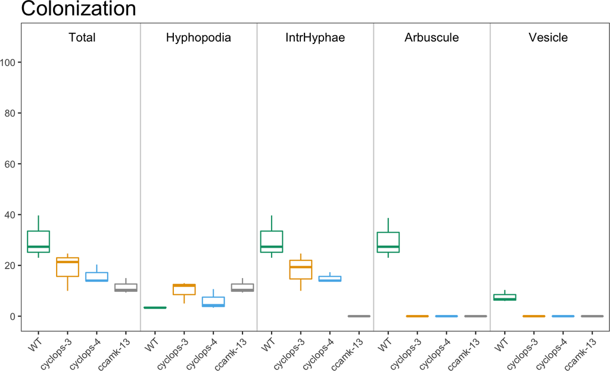

```r
am_boxplot(gr)
```

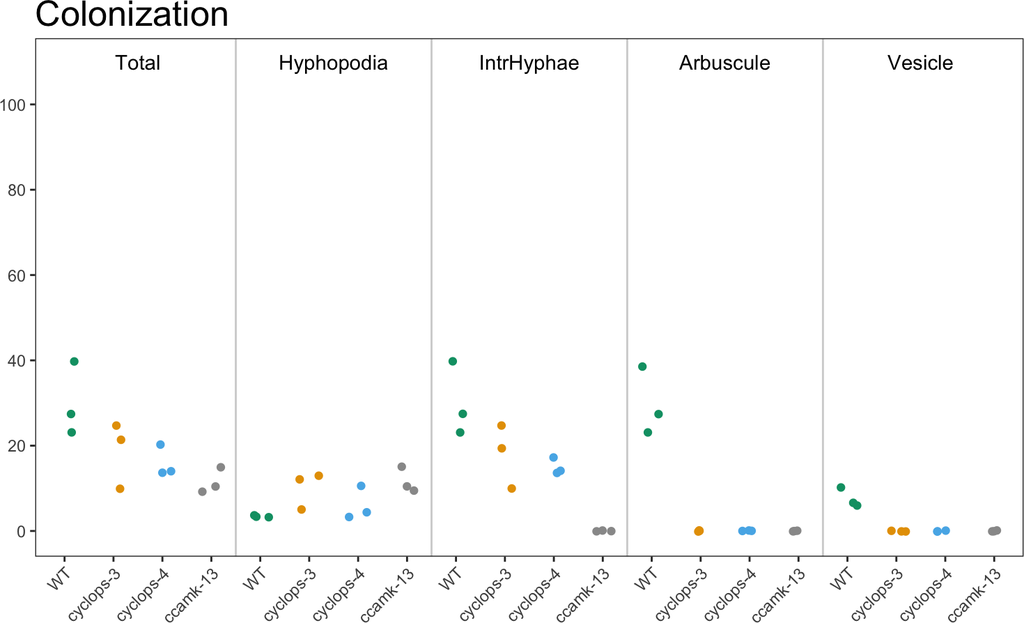

```r
am_dotplot(gr)
```

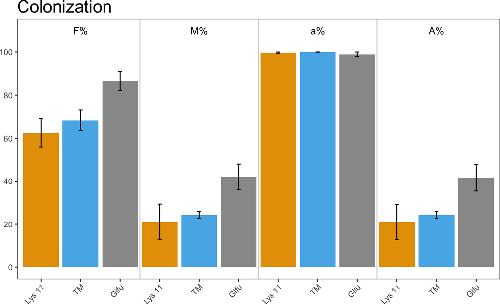

```r
am_barplot(tr)
```

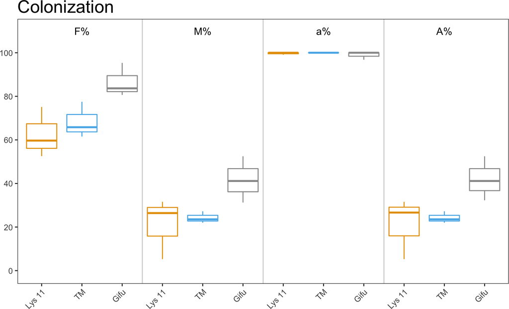

```r
am_boxplot(tr)
```

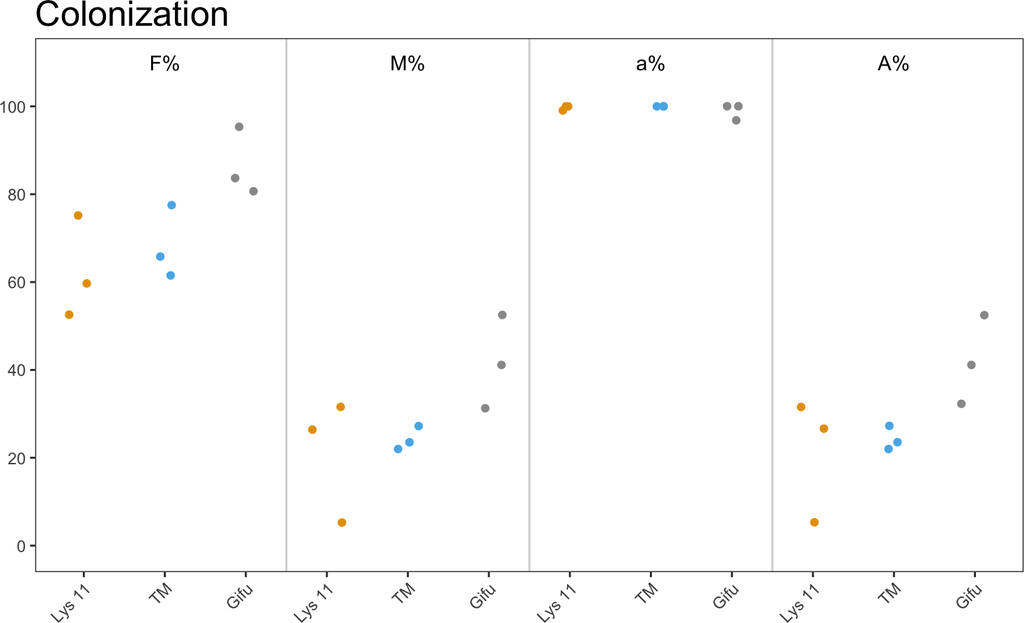

```r
am_dotplot(tr)
```

The plot fuctions take a set of option to customize your plot.

#### 0.0.5.2 Example

The plot can use different color palettes. We advise to use [Colorbrewer](http://colorbrewer2.org/#type=sequential&scheme=BuGn&n=3) or [Colorgorical](http://vrl.cs.brown.edu/color).

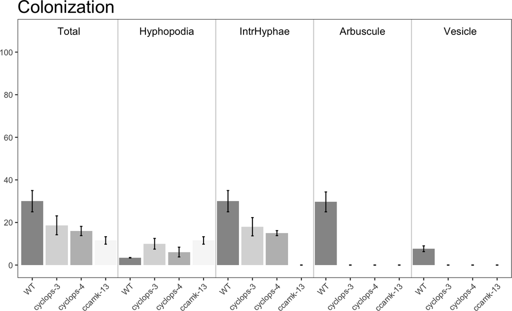

```r
am_barplot(gr, cbPalette = c('#f7f7f7', '#d9d9d9', '#bdbdbd', '#969696'))
```

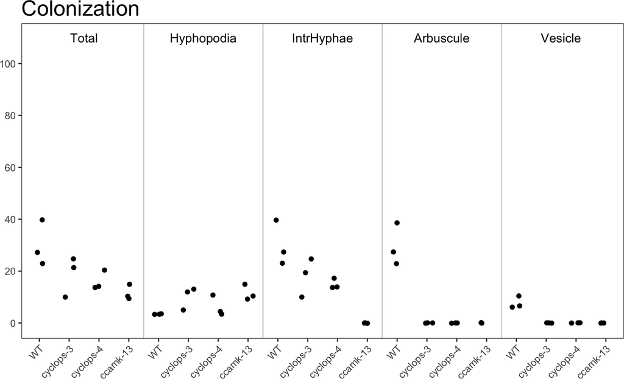

```r
am_dotplot(gr, cbPalette = rep("black", 4))
```

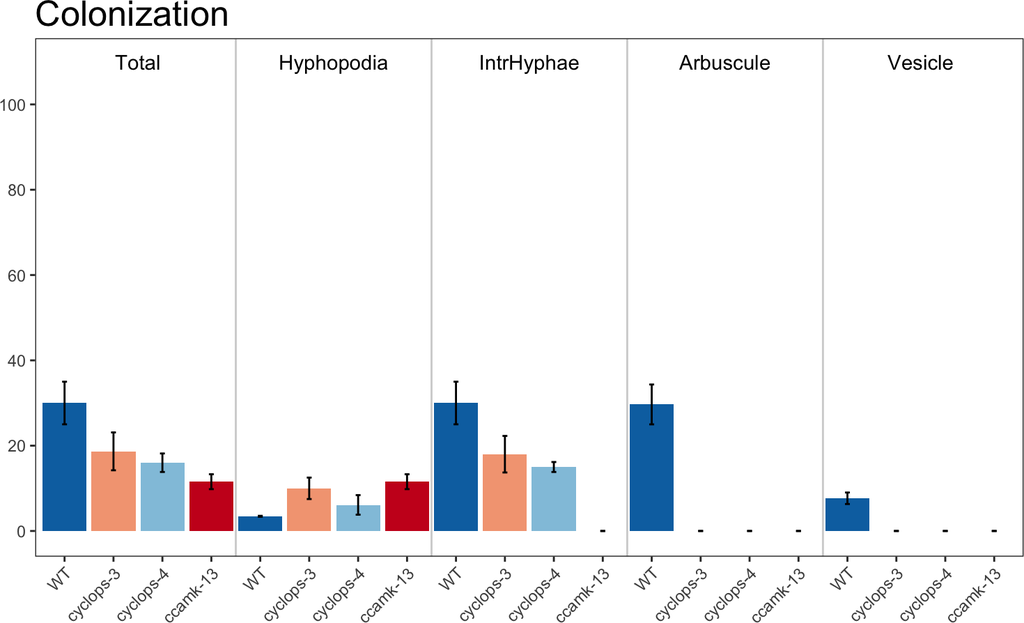

```r
am_barplot(gr, cbPalette = c('#ca0020', '#f4a582', '#92c5de', '#0571b0'))
```

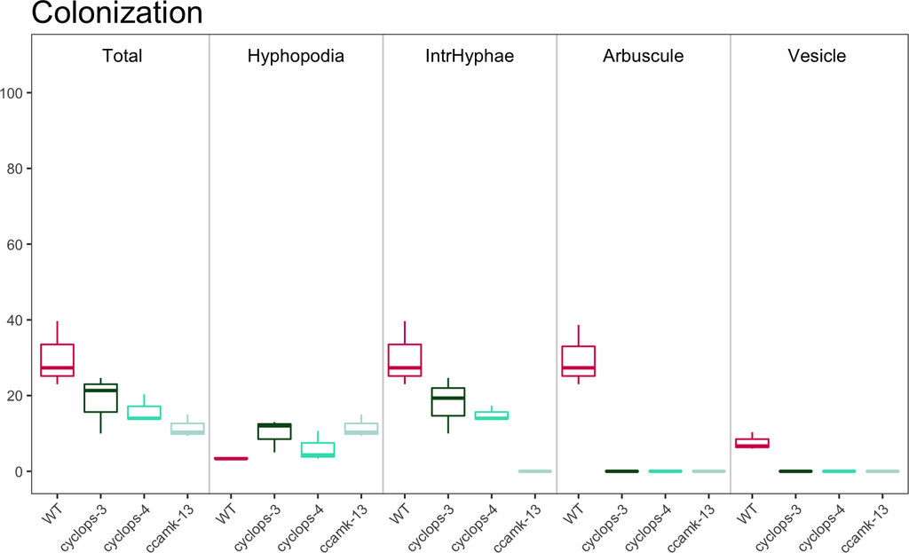

```r
am_boxplot(gr, cbPalette = c("#b4ddd4", "#02531d", "#34debb", "#d10f55"))
```

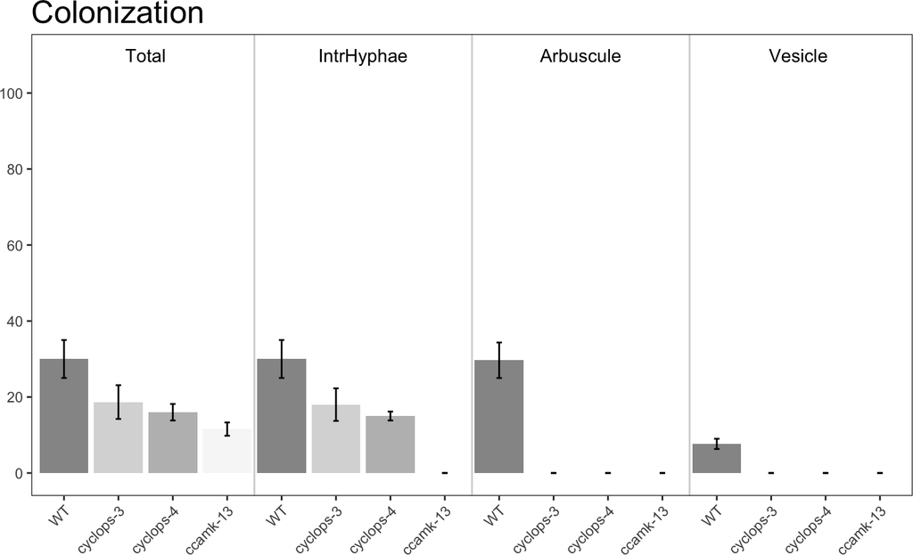

```r
am_barplot(gri, cbPalette = c('#f7f7f7', '#d9d9d9', '#bdbdbd', '#969696'))
```

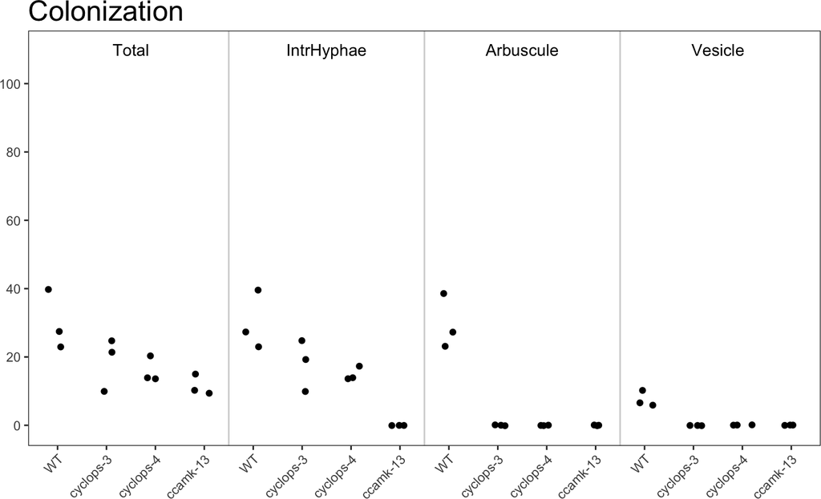

```r
am_dotplot(gri, cbPalette = rep("black", 4))
```

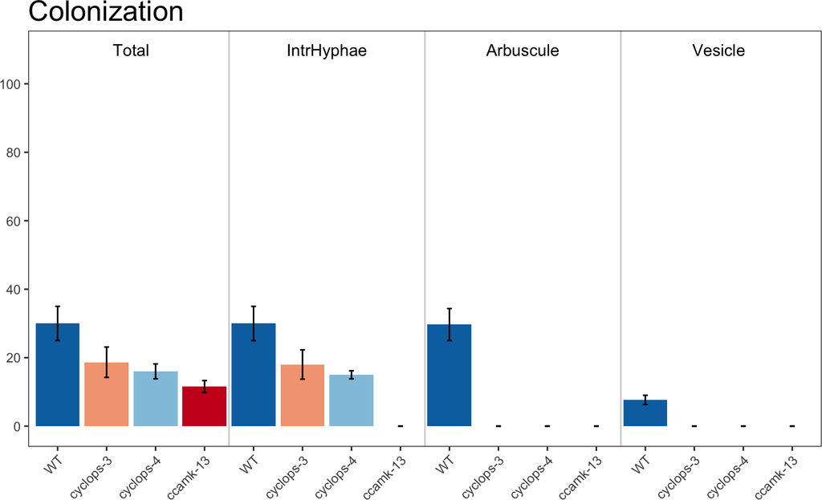

```r
am_barplot(gri, cbPalette = c('#ca0020', '#f4a582', '#92c5de', '#0571b0'))
```

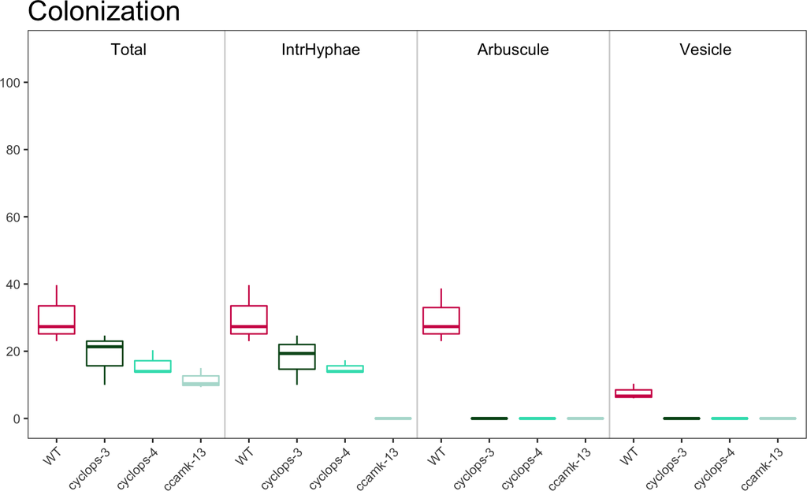

```r
am_boxplot(gri, cbPalette = c("#b4ddd4", "#02531d", "#34debb", "#d10f55"))
```

The title of the plot can be changed

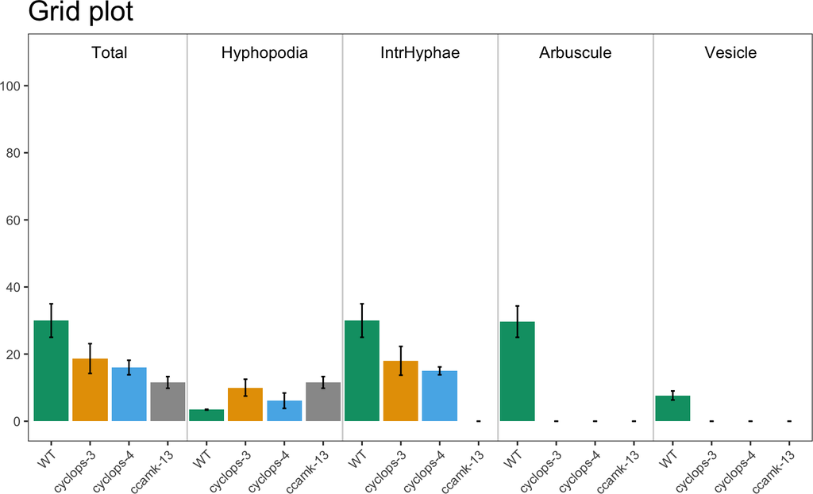

```r
am_barplot(gr, main = "Grid plot")
```

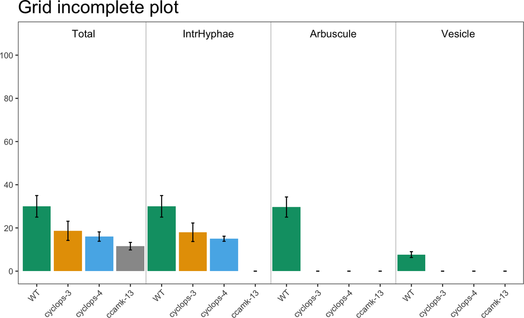

```r
am_barplot(gri, main = "Grid incomplete plot")
```

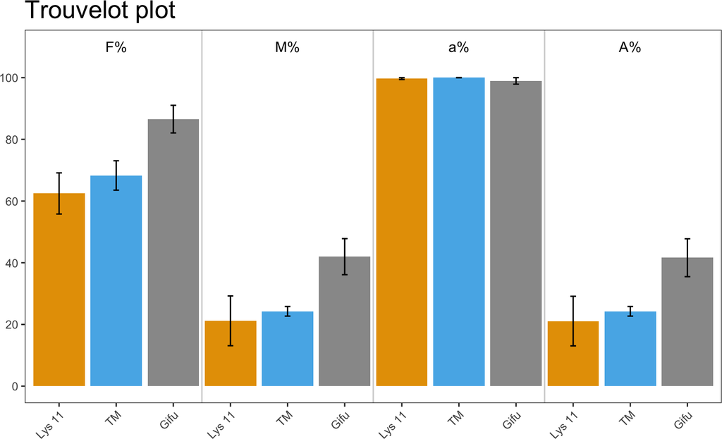

```r
am_barplot(tr, main = "Trouvelot plot")
```

The plotting system is based on [ggplot2](http://ggplot2.org/), so is possible to change some parameters

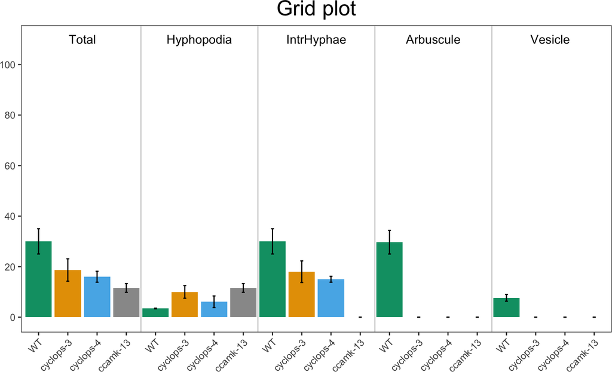

```r
library(ggplot2)
am_barplot(gr, main = "Grid plot") + theme(plot.title = element_text(hjust = .5))
```

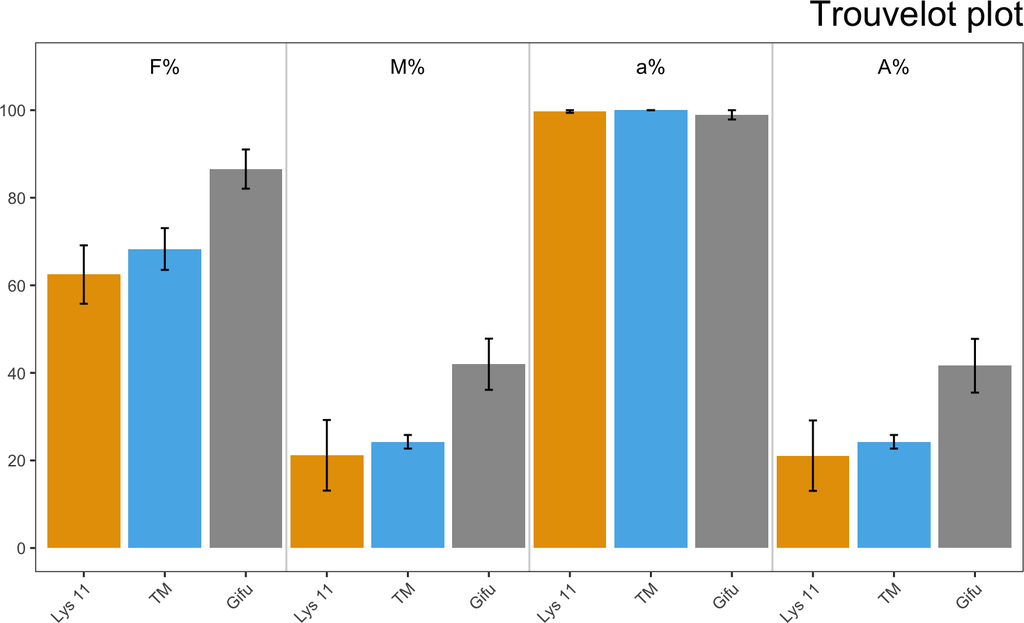

```r
am_barplot(tr, main = "Trouvelot plot") + theme(plot.title = element_text(hjust = 1))
```

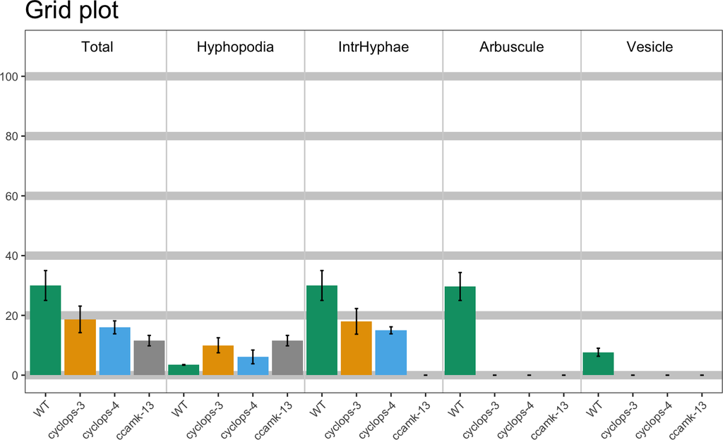

```r
am_barplot(gr, main = "Grid plot") + theme(panel.grid.major.y = element_line(size = 3, colour = "grey80"))
```

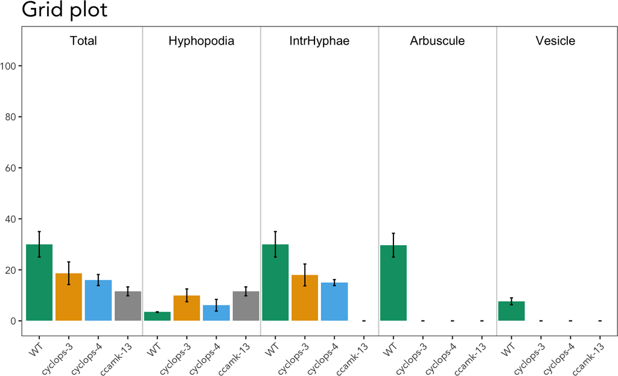

```r
am_barplot(gr, main = "Grid plot") + theme(text=element_text(family="Avenir"))
```

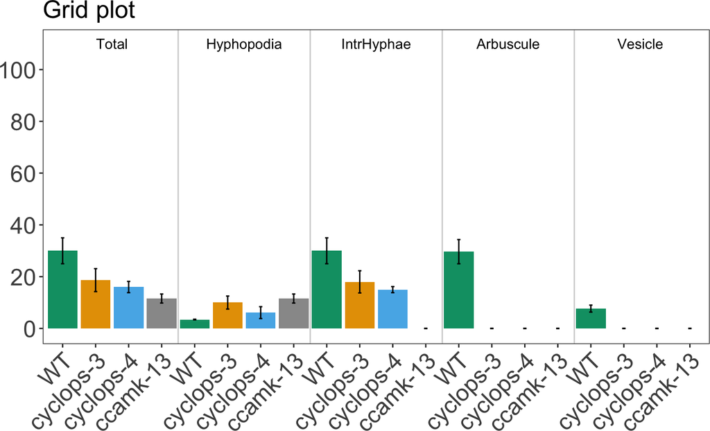

```r
am_barplot(gr, main = "Grid plot") + theme(axis.text = element_text(size = 18))
```

It is also possible to include the statistical results under the plot with the appropriate alpha

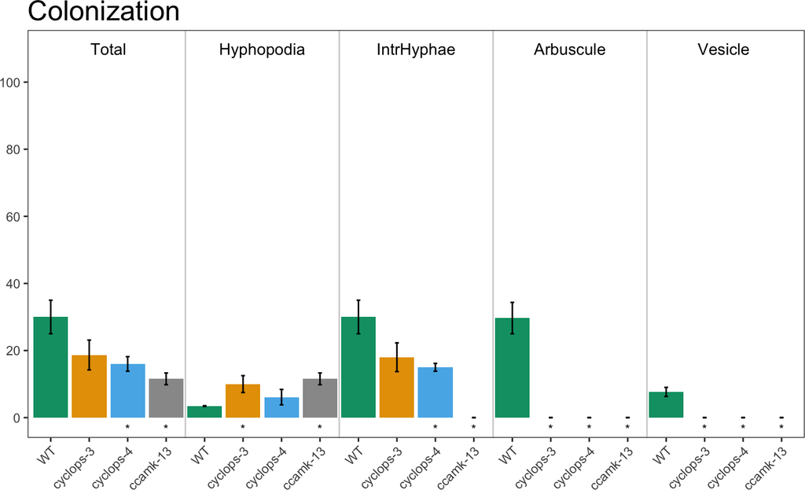

```r
am_barplot(gr, annot = "asterisks", alpha = 0.05)
```

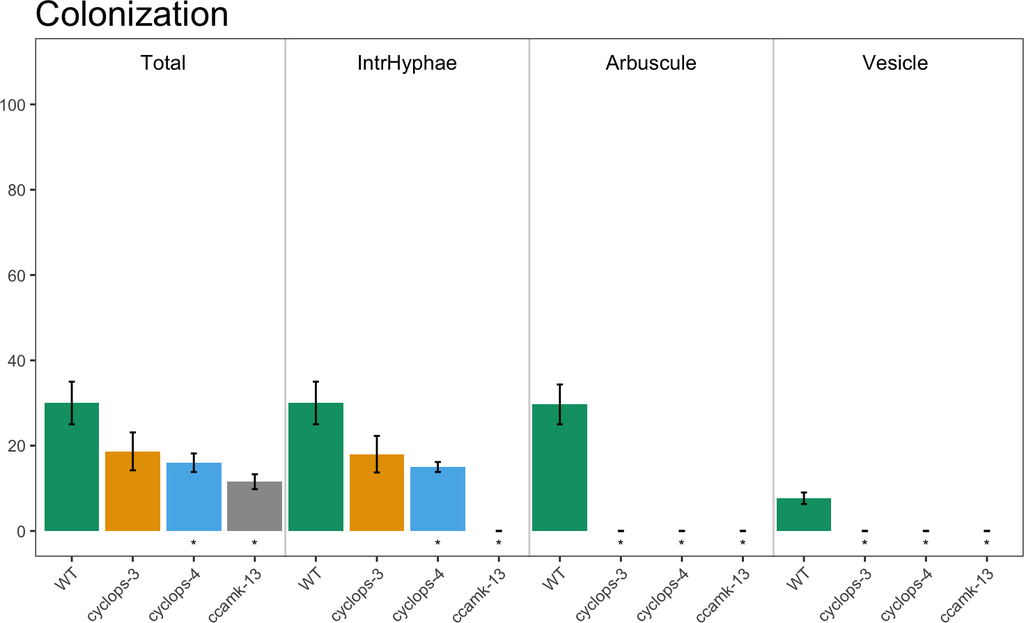

```r
am_barplot(gri, annot = "asterisks", alpha = 0.05)
```

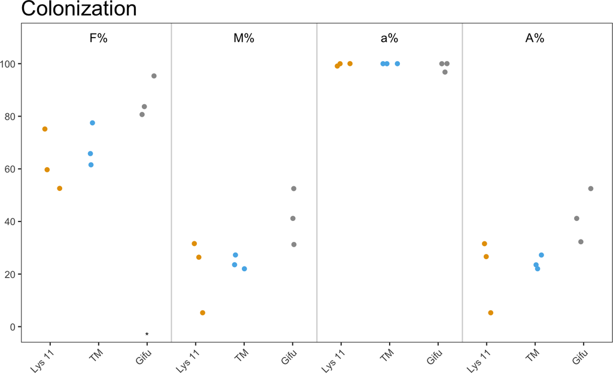

```r
am_dotplot(tr, annot = "asterisks", alpha = 0.01)
```

The asterisks below the plot show which sample is significant different from the control. The control is always the first element of the list.

It is also possible to include the statistical correction for the pvalues.

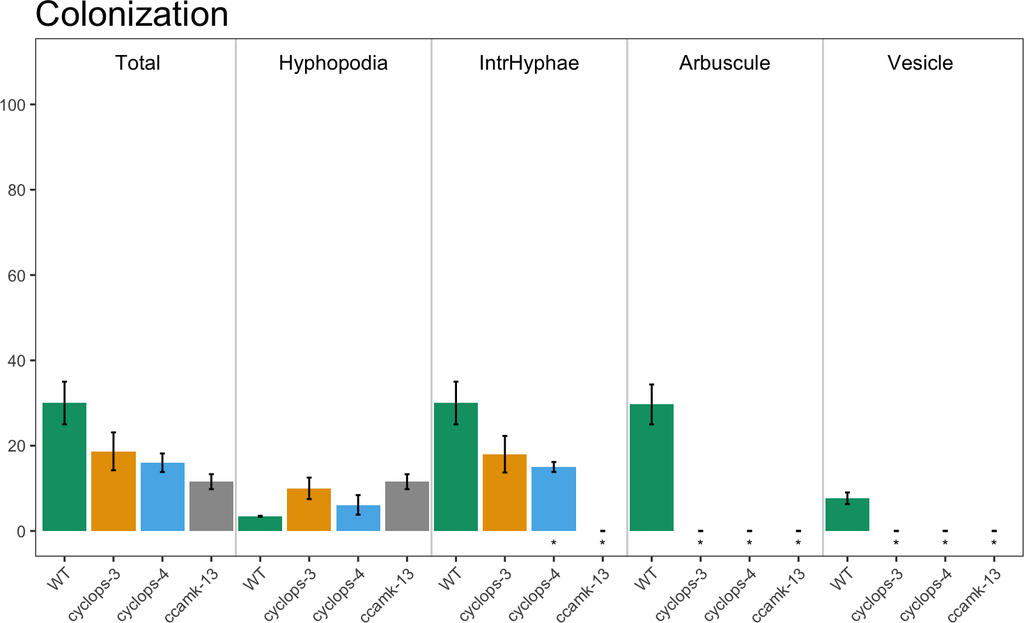

```r
am_barplot(gr, annot = "asterisks", method = "BH")
```

The asterisks allow to grafically dispay the statistical difference between the control sample and the other samples. If you want show the statistical difference between all the samples, you can add “letters” to the plot. Letters group the samples accordingly to they statistical difference.

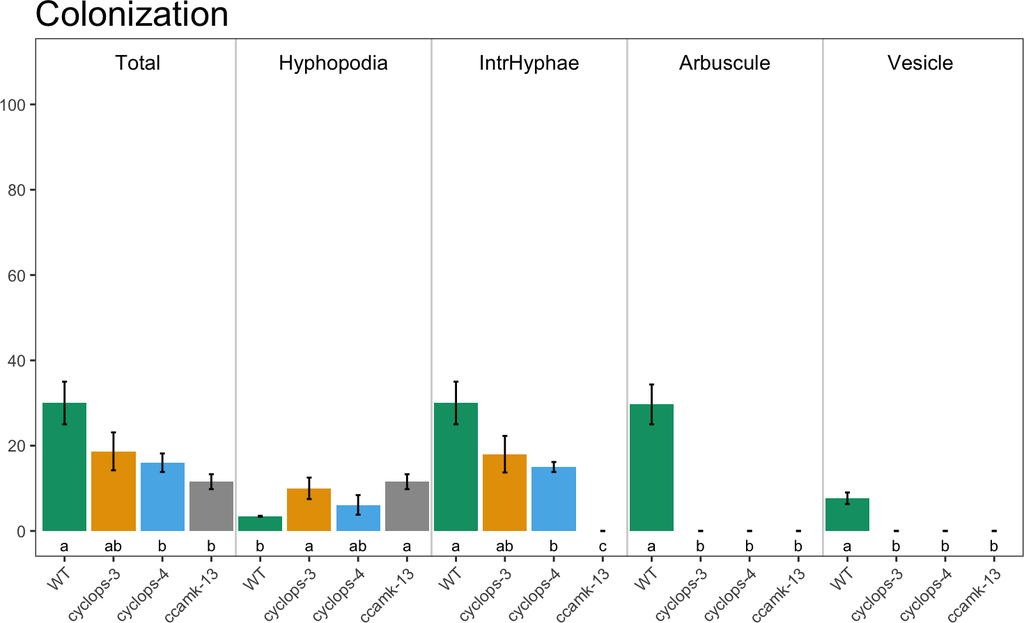

```r
am_barplot(gr, annot = "letters", alpha = 0.05)
```

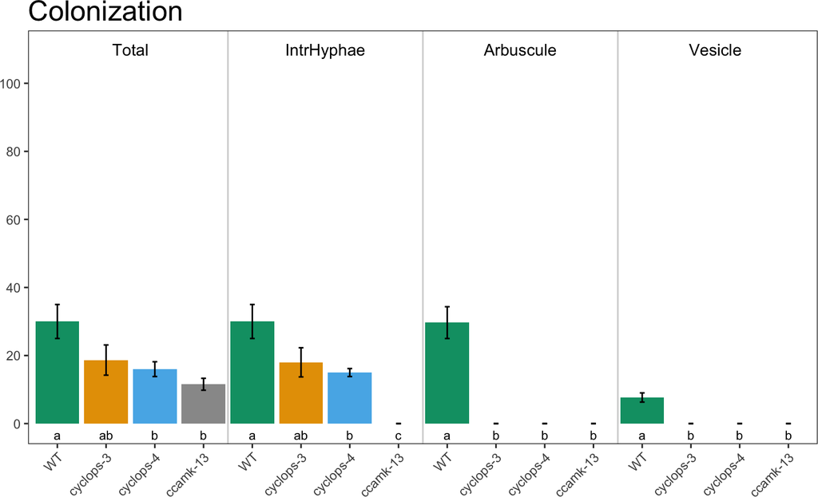

```r
am_barplot(gri, annot = "letters", alpha = 0.05)
```

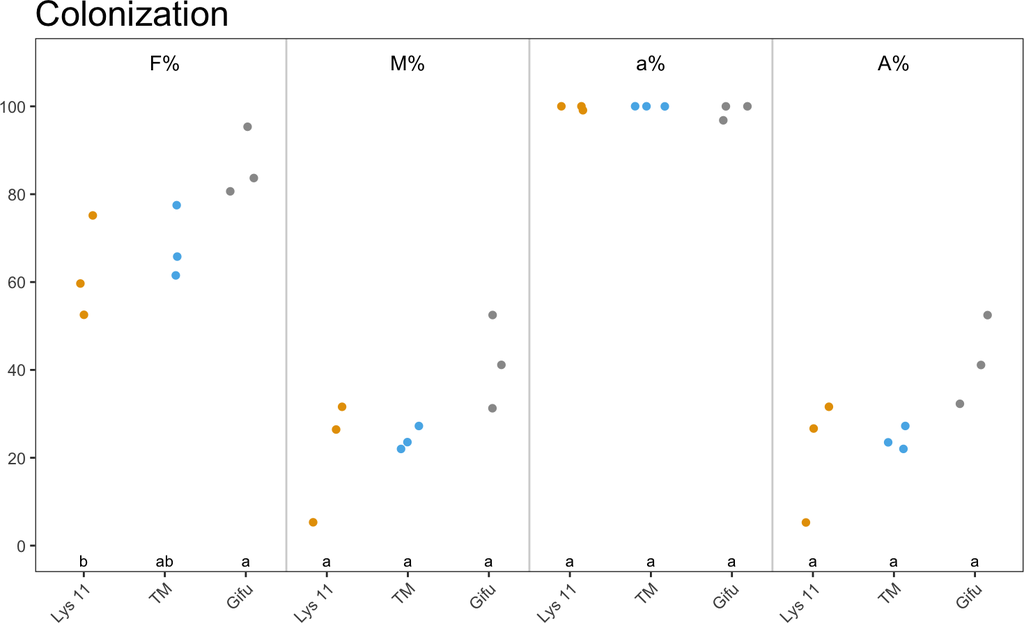

```r
am_dotplot(tr, annot = "letters", alpha = 0.01)
```

### 0.0.6 Save data

To export the data, a “save data” function is provided.

- **Summary data**: the function exports both the summary per replicate and the summary per sample in two distinct csv files.
- **Statistical data**: the function exports a csv file
- **Plots**: the function exports the plots and useful options can be used to export a pubblication ready image.

#### 0.0.6.1 Example

[figure not shown]

```r
# Save the summary
am_save(grs) # Two files will be saved: Summary_per_Replicate.csv and Summary_per_Sample.csv
am_save(trs, "Trouvelot") # Two files will be saved: Trouvelot_per_Replicate.csv and Trouvelot_per_Sample.csv

# Save the statisticas
am_save(am_stat(gr)) # One file called Summary_Stat.csv will be saved
am_save(am_stat(tr, method = "BH"), "Trouvelot") # One file called Trouvelot_stat.csv will be saved

# Save the plots
am_save(am_barplot(gr), "barplor_grid.pdf")
p1 <- am_barplot(gr, cbPalette = c('#f7f7f7', '#d9d9d9', '#bdbdbd', '#969696'), main = "Trouvelot", annot = "letters", method = "BH")
```

```r
am_save(p1, "dotplor_trouvelot.pdf", width = 21, height = 21, units = "cm", dpi = 300)

# Save jpg plot
am_save(p1, "dotplor_trouvelot.jpg")
```

### 0.0.7 Time series analysis

The package contains functions able to deal with time course data.

#### 0.0.7.1 Grid scoring system for time point data

The data should be provided in a **csv table** like the follow one:

| samples | replicates | time | Total | Hyphopodia | IntrHyphae | Arbuscule | Vesicle |
| --- | --- | --- | --- | --- | --- | --- | --- |
| WT | A | 4 | 30 | 3 | 30 | 30 | 10 |
| WT | A | 4 | 24 | 5 | 24 | 24 | 7 |
| WT | B | 4 | 20 | 2 | 20 | 20 | 5 |
| WT | B | 5 | 15 | 2 | 15 | 15 | 3 |
| cyclops-3 | A | 5 | 18 | 6 | 18 | 9 | 0 |
| cyclops-3 | A | 5 | 16 | 10 | 10 | 0 | 0 |
| cyclops-3 | B | 6 | 20 | 12 | 20 | 0 | 0 |
| cyclops-3 | B | 6 | 14 | 4 | 14 | 0 | 0 |
| … | … | … | … | … | … | … | … |

The table contains:

- 8 columns with **specific headers**
- The first 3 columns (samples, replicates and time) must be present
- The last 5 columns (Total, Hyphopodia, IntHyphae, Arbuscule and Vesicle) could not be all present
- If the headers are not the same of the ones in the example table the software will not be able to read the table
- As many row as you need
- The **first element of column “samples” will be used as control** for the statistical analysis (in this example “WT” will be used as control)

### 0.0.8 Loading time point data

To load data in, use the follow command:

> readDataTime(file.csv, type = c(“grid”, “trouvelot”))

#### 0.0.8.1 Example

```r
# Grid
f <- dir(system.file("extdata", package = "Ramf"), full.names = TRUE, pattern = "gridTime.csv")
tgr <- readDataTime(f, type = "grid")
```

It is very important the order of the samples in the csv file. The first sample will be considered the control.

### 0.0.9 Summarize data

To summarise the data and export the scoring results in a tabular format use the follow command:

> am_summary

#### 0.0.9.1 Example

```r
tgrs <- am_summary(tgr)
tgrs
```

```
## $`Summary per Replicate`
## # A tibble: 63 x 6
##    samples  time replicates    Total Arbuscule Vesicle
##      <chr> <int>      <chr>    <dbl>     <dbl>   <dbl>
##  1     HP0     4          1 96.04402 38.524156      39
##  2     HP0     4          2 68.72377 24.878951      31
##  3     HP0     4          3 63.27831  5.896523      38
##  4     HP0     4          4 51.29247 72.738523      19
##  5     HP0     4          5 49.31339 91.633666      40
##  6     HP0     4          6 21.06980  9.673359      41
##  7     HP0     4          7 86.06201 57.289660      39
##  8     HP0     4          8 69.30023 42.047067      27
##  9     HP0     5          1 33.13112 71.266821      51
## 10     HP0     5          2 11.50124 21.005316      31
## # ... with 53 more rows
##
## $`Summary per Sample`
## # A tibble: 9 x 8
## # Groups:   samples [3]
##   samples  time Total_mean Arbuscule_mean Vesicle_mean  Total_se
##     <chr> <int>      <dbl>          <dbl>        <dbl>     <dbl>
## 1     HP0     4   63.13550       42.83524     34.25000  8.214404
## 2     HP0     5   46.84563       37.64580     31.66667 14.777457
## 3     HP0     6   48.76365       38.12101     36.20000 15.733868
## 4    HP10     4   30.99651       40.55723     33.85714 10.146611
## 5    HP10     5   58.39261       30.28241     45.33333 10.679625
## 6    HP10     6   45.29252       55.38945     40.83333 14.432018
## 7     HP2     4   62.15865       29.93058     37.16667 11.630369
## 8     HP2     5   47.24082       51.33334     42.44444 10.689892
## 9     HP2     6   42.76423       52.34317     40.00000 12.610583
## # ... with 2 more variables: Arbuscule_se <dbl>, Vesicle_se <dbl>
##
## attr(,"class")
## [1] "am_summary" "list"
```

### 0.0.10 Statistical analysis

The statistical analysis is performed using the `kruskal` function from `agricolae` package. To read more about the statatical framework, refer to this [link](https://en.wikipedia.org/wiki/Kruskal%E2%80%93Wallis_one-way_analysis_of_variance).

> am_stat

#### 0.0.10.1 Example

```r
tgrst <- am_stat(tgr)
tgrst
```

```
## $`Stat per sample`
##    group1 group2 Total.pval Arbuscule.pval Vesicle.pval
## 1   HP0_4  HP0_5     0.3699         0.7393       0.7848
## 2   HP0_4  HP0_6     0.4546         0.6882       0.4534
## 9   HP0_5  HP0_6     0.9229         0.9354       0.3435
## 22 HP10_4 HP10_5     0.1148         0.5220       0.0751
## 23 HP10_4 HP10_6     0.4879         0.5073       0.0804
## 27 HP10_5 HP10_6     0.4299         0.1921       0.8846
## 34  HP2_4  HP2_5     0.3391         0.2153       0.1920
## 35  HP2_4  HP2_6     0.2795         0.2246       0.7877
## 36  HP2_5  HP2_6     0.8444         0.9643       0.2836
##
## $`Stat per time point`
##    group1 group2 Total.pval Arbuscule.pval Vesicle.pval
## 3   HP0_4 HP10_4     0.0674         0.9508       0.7846
## 6   HP0_4  HP2_4     0.9902         0.4228       0.4390
## 24 HP10_4  HP2_4     0.0903         0.4708       0.3159
## 11  HP0_5 HP10_5     0.5339         0.7394       0.0864
## 14  HP0_5  HP2_5     0.9597         0.4452       0.0198
## 29 HP10_5  HP2_5     0.4525         0.2227       0.4674
## 18  HP0_6 HP10_6     0.8078         0.3514       0.4922
## 21  HP0_6  HP2_6     0.7533         0.4185       0.8104
## 33 HP10_6  HP2_6     0.9473         0.8694       0.6198
##
## attr(,"class")
## [1] "am_statime" "list"
```

By default, the correction method is “none”, but it is possible to select between: Bonferroni, Holm, Hochberg, Bonferroni, Benjamini-Hochberg, Benjamini-Yekutieli or fdr adjustment. For more details refer to [agricolae package](https://cran.r-project.org/web/packages/agricolae/index.html).

#### 0.0.10.2 Example

```r
am_stat(tgr, method = "BH")
```

```
## $`Stat per sample`
##    group1 group2 Total.pval Arbuscule.pval Vesicle.pval
## 1   HP0_4  HP0_5     0.8736         0.9506       0.8841
## 2   HP0_4  HP0_6     0.8736         0.9506       0.7314
## 9   HP0_5  HP0_6     0.9871         0.9643       0.6508
## 22 HP10_4 HP10_5     0.8736         0.9506       0.4617
## 23 HP10_4 HP10_6     0.8736         0.9506       0.4617
## 27 HP10_5 HP10_6     0.8736         0.9506       0.9367
## 34  HP2_4  HP2_5     0.8736         0.9506       0.6036
## 35  HP2_4  HP2_6     0.8736         0.9506       0.8841
## 36  HP2_5  HP2_6     0.9871         0.9643       0.6508
##
## $`Stat per time point`
##    group1 group2 Total.pval Arbuscule.pval Vesicle.pval
## 3   HP0_4 HP10_4     0.8736         0.9643       0.8841
## 6   HP0_4  HP2_4     0.9902         0.9506       0.7314
## 24 HP10_4  HP2_4     0.8736         0.9506       0.6508
## 11  HP0_5 HP10_5     0.8736         0.9506       0.4617
## 14  HP0_5  HP2_5     0.9871         0.9506       0.3043
## 29 HP10_5  HP2_5     0.8736         0.9506       0.7314
## 18  HP0_6 HP10_6     0.9871         0.9506       0.7314
## 21  HP0_6  HP2_6     0.9871         0.9506       0.8841
## 33 HP10_6  HP2_6     0.9871         0.9610       0.7969
##
## attr(,"class")
## [1] "am_statime" "list"
```

The function reports the statistical analysis between the samples at the same time point and the statistical analysis of the same sample at different time points.